# Univariate Analysis

2024-09-30

```r
library(moments)
```

```r
# Reading in the data
Sale_Price <- read.csv("Sales_data.csv",header=T)
```

# Summary Statistics

```r
summary(Sale_Price)
```

```
##  unit_sale_price_gbp
##  Min.   : 0.0531
##  1st Qu.: 3.2870
##  Median :10.0024
##  Mean   :12.5501
##  3rd Qu.:18.8091
##  Max.   :70.5735
```

```r
# Calculate and print summary statistics for unit_sale_price_gbp
mean_unit_sale_price_gbp <- mean(Sale_Price$unit_sale_price_gbp)
median_unit_sale_price_gbp <- median(Sale_Price$unit_sale_price_gbp)
sd_unit_sale_price_gbp <- sd(Sale_Price$unit_sale_price_gbp)
var_unit_sale_price_gbp <- var(Sale_Price$unit_sale_price_gbp)
skewness_unit_sale_price_gbp <- skewness(Sale_Price$unit_sale_price_gbp)
kurtosis_unit_sale_price_gbp <- kurtosis(Sale_Price$unit_sale_price_gbp)

# Print the results
print(paste0("Mean: ", mean_unit_sale_price_gbp))
```

```
## [1] "Mean: 12.550068731976"
```

```r
print(paste0("Median: ", median_unit_sale_price_gbp))
```

```
## [1] "Median: 10.002398097"
```

```r
print(paste0("Standard Deviation: ", sd_unit_sale_price_gbp))
```

```
## [1] "Standard Deviation: 11.3248868529429"
```

```r
print(paste0("Variance: ", var_unit_sale_price_gbp))
```

```
## [1] "Variance: 128.253062231958"
```

```r
print(paste0("Skewness: ", skewness_unit_sale_price_gbp))
```

```
## [1] "Skewness: 1.38015163225954"
```

```r
print(paste0("Kurtosis: ", kurtosis_unit_sale_price_gbp))
```

```
## [1] "Kurtosis: 5.20636911964138"
```

# Analysis of results

Adressing the skewness of the data. The mean of the data is larger than the median, as wel las a skewness value of 1.38 suggesting that the data is *right skewed*

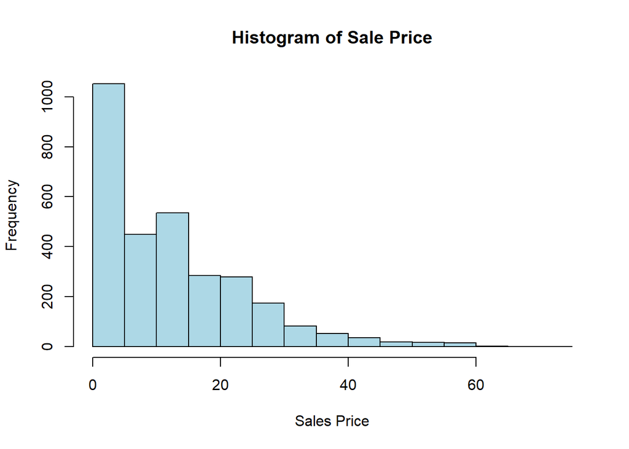

```r
# Histogram
hist(Sale_Price$unit_sale_price_gbp,main = "Histogram of Sale Price" ,xlab = "Sales Price", ylab = "Frequency", col = "lightblue")
```

This histogram has a long tail towards the right (right skew). This can be stastically represented by Kurtosis of 5.21 which indicates the heavy tail.

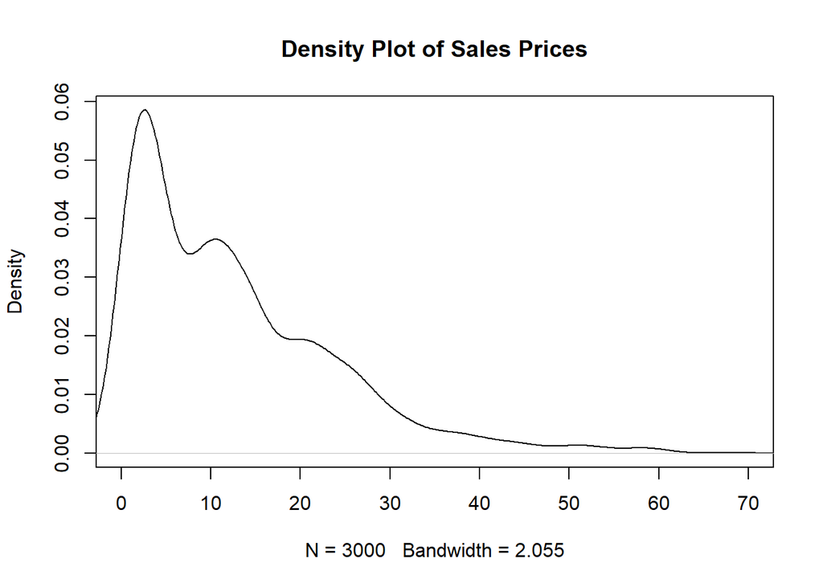

```r
# Density Plot
plot(density(Sale_Price$unit_sale_price_gbp), main = "Density Plot of Sales Prices", xlim = c(0,70))
```

# Testing for Normality

The normality of data can affect the choice of stastical tests and models created. The shape of the data suggests that it does not follow a normal distribution but there are additional tests that we can use. The example I’ve used here is a *Shapiro-Wilk* test

```r
# Shapiro Test
shapiro.test(Sale_Price$unit_sale_price_gbp)
```

```
##
##  Shapiro-Wilk normality test
##
## data:  Sale_Price$unit_sale_price_gbp
## W = 0.8744, p-value < 2.2e-16
```

This test gave a very small p value. Meaning we can say with confidence that the data is not normally distributed. This can be visualised in a Q-Q plot. The closer the points are to the normal line, the more likely the data follows a normal distribution

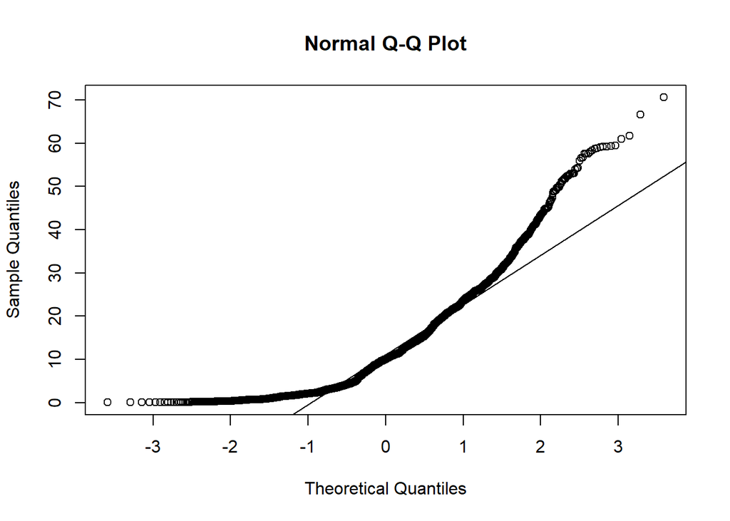

```r
# Q-Q Plot
qqnorm(Sale_Price$unit_sale_price_gbp)
qqline(Sale_Price$unit_sale_price_gbp)
```

# Investigating outliers

We know from the shape of the histogram and the Kurtosis value that there are some large values that are skewing the data. These can be visualised by a boxplot

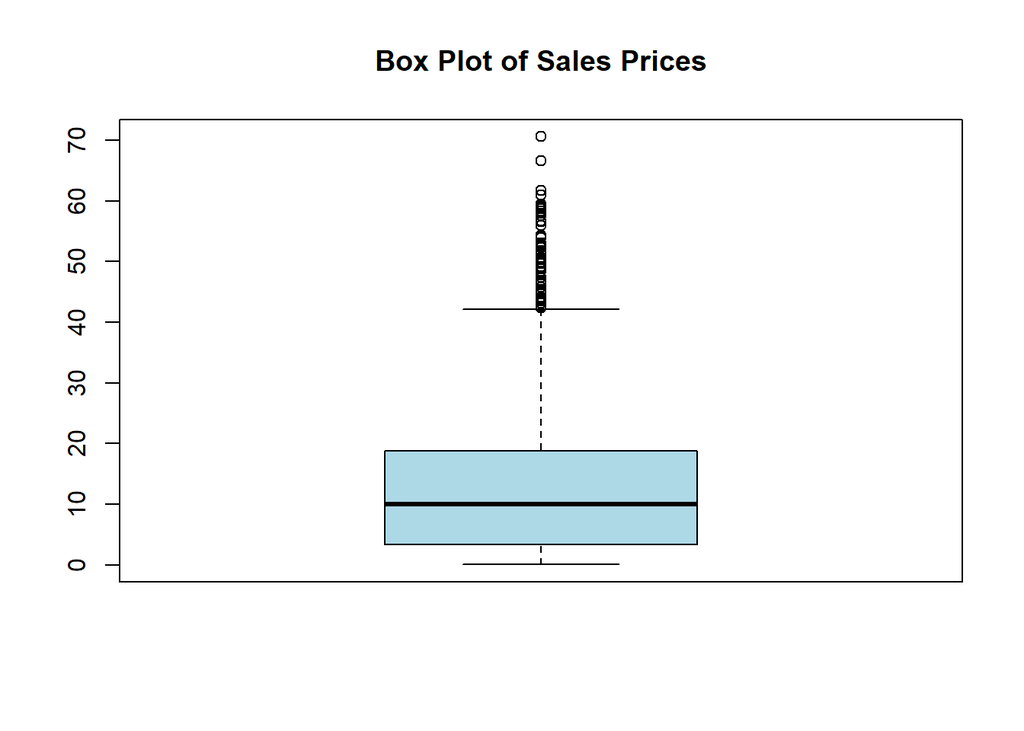

```r
# Boxplot
boxplot(Sale_Price$unit_sale_price_gbp,main = "Box Plot of Sales Prices", col = "lightblue")
```

This boxplot shows that there are values that are outside limits to be considered an outlier and and will skew the data.

# Conclusions

This dataset has a wide variance, numbers are spread far out and there are extremes at the larger end that are causing right skew

The mean of this data will not be ideal to use as there are distruptions to the *central tendancy of the data*. In this case it will be most useful to use the **median** instead of the mean. As it is less affected by the skew of the data and will be more representative of an average unit price